# docking_hits

```python
%load_ext autoreload
%autoreload 2
from pathlib import Path
import logging
from src.docking import Dock, visualise_complex, fix_protein, visualise_interactions
from rdkit import Chem
from rdkit.Chem import rdFMCS
from rdkit.Chem import PandasTools
import pandas as pd
import rdkit
import seaborn as sns
from src.qed import default, properties
from p_tqdm import p_map
from rdkit.Chem import rdFingerprintGenerator
from rdkit import DataStructs
from rdkit.ML.Cluster import Butina
from rdkit.Chem import Draw
from rdkit.Chem import rdFingerprintGenerator
from rdkit.Chem import AllChem
import numpy as np
from src.sascorer import calculateScore
import espsim
```

```
The autoreload extension is already loaded. To reload it, use:
  %reload_ext autoreload
```

#### Methodology:

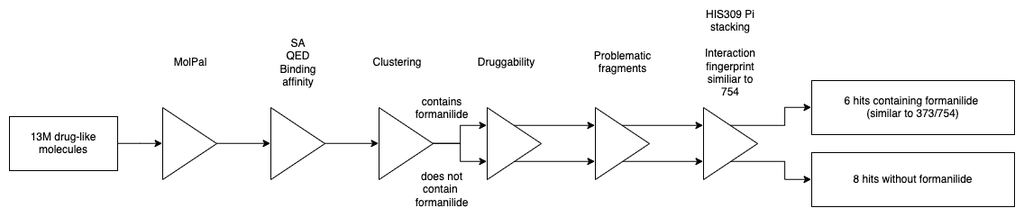

- Due to the computational resource required to perform a docking screen over a large library, we use an active learning module (MolPal) to learn a cheaper surrogate model, which iteratively learns from our previous docking scores and predicts which are of the chemical space of the library are most promising. We encourage exploration over exploitation, and include 10% random molecules in each iteration. Using MolPal and Smina, we screen 13M drug-like molecules in ZINC13 and find the approximate top 150k ligands (This model is still running, and will eventually select the top 400k hits). We use the center of mass of the allosterically-bound 373 fragment as the center of the docking bounding box, with a size box of 20 angstrom.
- We filter the top 150k hits by sythetic accessibilty (2<SA<4), drug-likeliness (QED>.5) and docking score (BA>10kcal/mol).
- We cluster the chemical space of drug-like hits using Taylor-Butina clustering.
- Next, we split the top hits into those including the formanilide substructure (the OSA_000373 fragment and known inhibitors OSA_000754, OSA_000742, OSA_000786) and those that do not include the substructure.
- For the 373-like hits, we take the top 1 hit from each cluster, and compute all ADME props using SwissADME. We filter to disclude any hits that do not pass all druggability filters (Lipinski, Ghose, Egan, Veber, Muegge), and filter out problematic fragments alerted by PAINS and Brenk filters. Then, we filter to molecules to those with i) HIS309 Pi stacking (a common interaction in the known inhibitors) and ii) have an interaction similarity to the most potent inhibitor (OSA_000754) of over 0.5. Finally, we plot the molecules and analyse the protein-ligand interactions and docking poses.
- We present the top 6 373-like hits, which all have favourable poses (anchored by pi stacking in HIS309, but with similiar pose and interactions to the potent 754 inhibitor), and favourable drug likeliness and synthetic accessability.
- For the non-373-like hits, we perform the same methodology as above, and find 8 hits.

Ultimately, due to the constaints we imposed to ensure similarity to the most potent inhibitor (754) and framgent (373), we find very similiar interaction fingerprints across both groups (with and without formanilide). Both groups contain pi stacking at HIS309 and PHE146, and an assortment of hydrophobic interactions along residues ~139-151.